# Title : AirBnB Listings and Reviews

## Name : Marishel Lochan

## Year : 2025

[figure not shown]

## Objective:

The objective of this project is to analyze AirBnB Listings in Paris to determine the impact of recent regulations

```python
!pip install matplotlib
```

[output not shown]

```python
import numpy as np
import pandas as pd
import matplotlib.pyplot as plt
```

## Data

The Airbnb data has about 250,000+ listings across 10 major cities, along with ~5 million guest reviews.

```python
listings = pd.read_csv('Listings.csv',encoding='latin1', low_memory=False)
listings.head()
```

|  | listing_id | name | host_id | host_since | host_location | host_response_time | host_response_rate | host_acceptance_rate | host_is_superhost | host_total_listings_count | ... | minimum_nights | maximum_nights | review_scores_rating | review_scores_accuracy | review_scores_cleanliness | review_scores_checkin | review_scores_communication | review_scores_location | review_scores_value | instant_bookable |
| --- | --- | --- | --- | --- | --- | --- | --- | --- | --- | --- | --- | --- | --- | --- | --- | --- | --- | --- | --- | --- | --- |
| 0 | 281420 | Beautiful Flat in le Village Montmartre, Paris | 1466919 | 2011-12-03 | Paris, Ile-de-France, France | NaN | NaN | NaN | f | 1.0 | ... | 2 | 1125 | 100.0 | 10.0 | 10.0 | 10.0 | 10.0 | 10.0 | 10.0 | f |
| 1 | 3705183 | 39 mÂ² Paris (Sacre CÃ âur) | 10328771 | 2013-11-29 | Paris, Ile-de-France, France | NaN | NaN | NaN | f | 1.0 | ... | 2 | 1125 | 100.0 | 10.0 | 10.0 | 10.0 | 10.0 | 10.0 | 10.0 | f |
| 2 | 4082273 | Lovely apartment with Terrace, 60m2 | 19252768 | 2014-07-31 | Paris, Ile-de-France, France | NaN | NaN | NaN | f | 1.0 | ... | 2 | 1125 | 100.0 | 10.0 | 10.0 | 10.0 | 10.0 | 10.0 | 10.0 | f |
| 3 | 4797344 | Cosy studio (close to Eiffel tower) | 10668311 | 2013-12-17 | Paris, Ile-de-France, France | NaN | NaN | NaN | f | 1.0 | ... | 2 | 1125 | 100.0 | 10.0 | 10.0 | 10.0 | 10.0 | 10.0 | 10.0 | f |
| 4 | 4823489 | Close to Eiffel Tower - Beautiful flat : 2 rooms | 24837558 | 2014-12-14 | Paris, Ile-de-France, France | NaN | NaN | NaN | f | 1.0 | ... | 2 | 1125 | 100.0 | 10.0 | 10.0 | 10.0 | 10.0 | 10.0 | 10.0 | f |

5 rows × 33 columns

## Objective 1

We needed to first AirBnB listings data, calculate basic profiling metrics, change column datatypes as necessary, and then filter down to only Paris Listings.

```python
pd.to_datetime(listings['host_since'])
```

```
0        2011-12-03
1        2013-11-29
2        2014-07-31
3        2013-12-17
4        2014-12-14
            ...
279707   2015-04-13
279708   2013-11-27
279709   2012-04-27
279710   2015-07-16
279711   2013-06-17
Name: host_since, Length: 279712, dtype: datetime64[ns]
```

- I then was able to filter to only the listings with the city "Paris"

```python
paris = listings['city']=='Paris'
print(paris)
```

```
0         True
1         True
2         True
3         True
4         True
          ...
279707    True
279708    True
279709    True
279710    True
279711    True
Name: city, Length: 279712, dtype: bool
```

```python
listings.isnull().sum()
```

```
listing_id                          0
name                              175
host_id                             0
host_since                        165
host_location                     840
host_response_time             128782
host_response_rate             128782
host_acceptance_rate           113087
host_is_superhost                 165
host_total_listings_count         165
host_has_profile_pic              165
host_identity_verified            165
neighbourhood                       0
district                       242700
city                                0
latitude                            0
longitude                           0
property_type                       0
room_type                           0
accommodates                        0
bedrooms                        29435
amenities                           0
price                               0
minimum_nights                      0
maximum_nights                      0
review_scores_rating            91405
review_scores_accuracy          91713
review_scores_cleanliness       91665
review_scores_checkin           91771
review_scores_communication     91687
review_scores_location          91775
review_scores_value             91785
instant_bookable                    0
dtype: int64
```

```python
most_frequent_date = listings['host_since'].mode()
listings['host_since'].fillna(most_frequent_date)
```

```
0         2011-12-03
1         2013-11-29
2         2014-07-31
3         2013-12-17
4         2014-12-14
             ...
279707    2015-04-13
279708    2013-11-27
279709    2012-04-27
279710    2015-07-16
279711    2013-06-17
Name: host_since, Length: 279712, dtype: object
```

```python
paris_listings = listings.loc[listings['city']=='Paris',['host_since','neighbourhood'
                                                                               ,'city'
                                                                               , 'accommodates',
                                                                               'price']]
print(paris_listings)
```

```
        host_since      neighbourhood   city  accommodates  price
0       2011-12-03  Buttes-Montmartre  Paris             2     53
1       2013-11-29  Buttes-Montmartre  Paris             2    120
2       2014-07-31             Elysee  Paris             2     89
3       2013-12-17          Vaugirard  Paris             2     58
4       2014-12-14              Passy  Paris             2     60
...            ...                ...    ...           ...    ...
279707  2015-04-13       Observatoire  Paris             2    120
279708  2013-11-27  Buttes-Montmartre  Paris             2     60
279709  2012-04-27  Buttes-Montmartre  Paris             2     50
279710  2015-07-16         Popincourt  Paris             2    105
279711  2013-06-17  Enclos-St-Laurent  Paris             2     70

[64690 rows x 5 columns]
```

- To understand the data a bit, I calcuated the mean, maximum and minimum of both the 'accommodates' and 'price' in the 'paris_listings'

```python
accommodation_avg = paris_listings['accommodates'].mean()
accommodation_minimum = paris_listings['accommodates'].min()
accommodation_maximum = paris_listings['accommodates'].max()
print(accommodation_avg)
print(accommodation_minimum)
print(accommodation_maximum)
```

```
3.0379965991652496
0
16
```

```python
price_avg = paris_listings['price'].mean()
price_minimum = paris_listings['price'].min()
price_maximum = paris_listings['price'].max()
print(price_avg)
print(price_minimum)
print(price_maximum)
```

```
113.09644458185191
0
12000
```

- I saw for both the 'accommodates' and 'price' columns had a minimum od zero, as such I filtered the 'paris_listings' to ensure that there were zeros in the dataset.

```python
paris_listings.loc[paris_listings['price'] == 0]
```

|  | host_since | neighbourhood | city | accommodates | price |
| --- | --- | --- | --- | --- | --- |
| 98209 | 2020-07-20 | Pantheon | Paris | 0 | 0 |
| 203257 | 2020-02-04 | Batignolles-Monceau | Paris | 0 | 0 |
| 203258 | 2016-10-17 | Opera | Paris | 0 | 0 |
| 203259 | 2020-04-24 | Luxembourg | Paris | 0 | 0 |
| 203260 | 2020-04-24 | Vaugirard | Paris | 0 | 0 |
| ... | ... | ... | ... | ... | ... |
| 208881 | 2020-10-22 | Pantheon | Paris | 0 | 0 |
| 208882 | 2020-11-26 | Enclos-St-Laurent | Paris | 0 | 0 |
| 208883 | 2020-11-26 | Vaugirard | Paris | 0 | 0 |
| 208884 | 2020-12-21 | Vaugirard | Paris | 0 | 0 |
| 212834 | 2020-02-03 | Enclos-St-Laurent | Paris | 0 | 0 |

62 rows × 5 columns

## Objective 2:

The second objective was to prepare the data for visualization and this meant filtering and querying the data to produce valuable information.

- Firstly, a table was created to list all the neighbourhoods in 'Paris' and calculate their average prices.

```python
paris_listings_neighbourhood = paris_listings.groupby('neighbourhood')['price'].mean().sort_values()
print(paris_listings_neighbourhood)
```

```
neighbourhood
Menilmontant            74.942257
Buttes-Chaumont         82.690182
Buttes-Montmartre       87.209479
Reuilly                 89.058402
Popincourt              90.559459
Gobelins                98.110184
Observatoire           101.866801
Batignolles-Monceau    102.612702
Enclos-St-Laurent      102.967156
Vaugirard              106.831330
Opera                  119.038644
Pantheon               122.662150
Temple                 138.446823
Hotel-de-Ville         144.472110
Bourse                 149.496801
Luxembourg             155.638639
Palais-Bourbon         156.856578
Passy                  161.144635
Louvre                 175.379972
Elysee                 210.536765
Name: price, dtype: float64
```

- The Second findings were listing the average prices of each accommodation in the most expensive neighbourhood in Paris

```python
men = paris_listings_neighbourhood.idxmax() # gets the max index
print(men)
```

```
Elysee
```

```python
men_listings= paris_listings.loc[paris_listings['neighbourhood']==men]
print(men_listings)
```

```
        host_since neighbourhood   city  accommodates  price
2       2014-07-31        Elysee  Paris             2     89
14      2015-12-30        Elysee  Paris             2     35
128     2015-03-26        Elysee  Paris             2     75
137     2015-08-23        Elysee  Paris             2     90
260     2014-07-18        Elysee  Paris             2    110
...            ...           ...    ...           ...    ...
278484  2016-07-22        Elysee  Paris             2     98
279043  2016-05-09        Elysee  Paris             2     75
279117  2014-11-20        Elysee  Paris             2    100
279299  2014-09-30        Elysee  Paris             2     87
279618  2013-04-15        Elysee  Paris             2    119

[1768 rows x 5 columns]
```

```python
paris_listings_accommodations = men_listings.groupby('accommodates')['price'].mean().sort_values()
print(paris_listings_accommodations)
```

```
accommodates
0       0.000000
1      79.522222
3     152.828767
2     155.103352
4     212.096070
5     328.817073
6     355.508571
8     405.518519
7     411.538462
9     440.272727
10    500.857143
12    529.625000
16    800.000000
11    805.000000
13    842.500000
14    971.000000
Name: price, dtype: float64
```

- Before proceeding, I took a look at the dataset to ensure I understand how I was going to filter the next table.

```python
paris_listings.info()
```

```
<class 'pandas.core.frame.DataFrame'>
Index: 64690 entries, 0 to 279711
Data columns (total 5 columns):
 #   Column         Non-Null Count  Dtype
---  ------         --------------  -----
 0   host_since     64657 non-null  object
 1   neighbourhood  64690 non-null  object
 2   city           64690 non-null  object
 3   accommodates   64690 non-null  int64
 4   price          64690 non-null  int64
dtypes: int64(2), object(3)
memory usage: 5.0+ MB
```

- Last Table created was to find the average prices as well as the number of new hosts over the period of time from the first listing to the last.
- Before filtering, I decided to split the 'host_since' date column and split the year, month and day into their own columns in the 'paris_listings' to make it easier to filter.

```python
dates = paris_listings['host_since'].str.split('-',expand=True)
print(dates)
```

```
           0   1   2
0       2011  12  03
1       2013  11  29
2       2014  07  31
3       2013  12  17
4       2014  12  14
...      ...  ..  ..
279707  2015  04  13
279708  2013  11  27
279709  2012  04  27
279710  2015  07  16
279711  2013  06  17

[64690 rows x 3 columns]
```

```python
paris_listings['Year'] = dates.iloc[:,0]
paris_listings['Month'] = dates.iloc[:,1]
paris_listings['Day'] = dates.iloc[:,2]
print(paris_listings)
```

[output not shown]

```python
paris_listings_over_time = paris_listings.groupby('Year').agg(averagePrice=('price','mean'),newHosts=('Year','count'))
print(paris_listings_over_time)
```

```
      averagePrice  newHosts
Year
2008     77.750000         4
2009    159.641509       106
2010    125.031250       416
2011    124.828230      1339
2012    111.578615      4592
2013    107.096414      8142
2014    100.253800     10922
2015    103.646250     12147
2016    114.159847      8871
2017    108.658888      4585
2018    138.209362      4294
2019    129.757113      5694
2020    141.456038      3412
2021     93.488722       133
```

## Objective3 : Visualization

```python
paris_listings_neighbourhood = paris_listings_neighbourhood.reset_index()# to get index
```

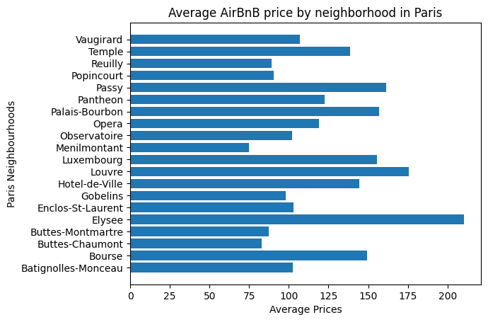

```python
plt.barh(paris_listings_neighbourhood['neighbourhood'], paris_listings_neighbourhood['price'])
plt.xlabel("Average Prices")
plt.ylabel("Paris Neighbourhoods")
plt.title("Average AirBnB price by neighborhood in Paris")
plt.show()
plt.clf()
```

```python
paris_listings_accommodations = paris_listings_accommodations.reset_index()
```

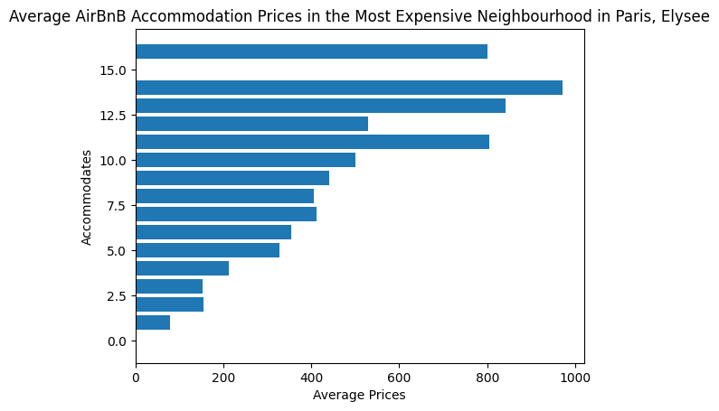

```python
plt.barh(paris_listings_accommodations['accommodates'],paris_listings_accommodations['price'])
plt.xlabel("Average Prices")
plt.ylabel("Accommodates")
plt.title("Average AirBnB Accommodation Prices in the Most Expensive Neighbourhood in Paris, " + men)
plt.show()
plt.clf()
```

```python
paris_listings_over_time = paris_listings_over_time.reset_index()
```

[figure not shown]

```python
plt.ploat(paris_listings_over_time['Year'], paris_listings_over_time['newHosts'])
plt.xticks(rotation=45)
plt.ylim(bottom=0)
plt.xlabel("Year")
plt.ylabel("New Hosts")
plt.title("New AirBnb Hosts over time in Paris")
plt.show()
plt.clf()
```

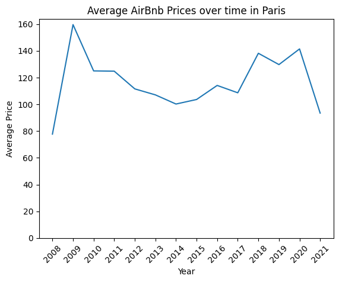

```python
plt.plot(paris_listings_over_time['Year'], paris_listings_over_time['averagePrice'])
plt.xticks(rotation=45)
plt.ylim(bottom=0)
plt.xlabel("Year")
plt.ylabel("Average Price")
plt.title("Average AirBnb Prices over time in Paris")
plt.show()
plt.clf()
```